# 826 Homework 1

## Noah Stafford

Homework Description “The experiment was carried out in a lab at the Department of Entomology, University of California, Berkeley. Mites were exposed in 11-14 groups of ten to a given dose of permethrin for a fixed interval of time, and the number of mites dead in each group of ten at the end of the interval was recorded. This was done for each of seven doses, expressed in grams of active ingredient per 100 liters.”

First, let’s look at the data in a couple of ways to gain a baseline understanding of the data and make sure there aren’t any obvious issues.

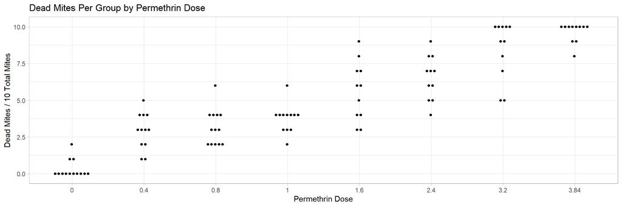

Let’s look at the number of experiments that were done at each doseage. It appears alternately 13 and 12 groups of 10 mites were tested for the lower doseages, and 11 groups for the higher doseages.

```
## # A tibble: 8 x 2
##   dose  number_of_experiments
##   <fct>                 <int>
## 1 0                        13
## 2 0.4                      12
## 3 0.8                      13
## 4 1                        12
## 5 1.6                      11
## 6 2.4                      11
## 7 3.2                      11
## 8 3.84                     11
```

1. Consider the data in hw1_mites.txt. At each of seven doses we have the number of dead out of ten, for between 11 and 14 groups of ten. Use this data to examine the hypothesis that at any given dose the mites are dying independently with a constant probability. Consider using computer simulations.

‘Hypothesis that the mites are dying independently at a constant probability’ suggests that we want to model the data with a binomial distribution with a different probability of dying p for every level of dose. This distribution assumes the observations are independent from each other. Since there are no covariates included in this dataset, simple analyses, such as looking at associations between covariates that varied across or within experiments, cannot be done. What remains to do is define a null model for the data, and rigoriously test to see if it is reasonable to say that the data could have come from this model.

Since we are only testing the independence of the observations conditional on the dose level, we only need to test the assumptions of independence within the doses, and hence only define the conditional distribution here:

X = # of dead mites

dose = Level of dose
$$X|dose \sim BN(10,p_{dose})$$

First, let’s apply some standard statistical analyses to the data to see if we can gain some understanding of how well the data is modeled by my proposed distribution. First, let’s run a goodness of fit test on the data, which tests to see if the counts in the observed data deviate significantly from the counts that would be expected if the data was being generated from my model.

There’s not much here. With 88 degrees of freedom, a 5% alpha gives us a critical value of 109.773, which is far above the calculated chi-squared statistic of 66.483 This result provides no evidence aginst the binomial model being an appropriate fit for the data.

However, this dataset is small. The number of observations within each dose level (10-13) is very small, and so these kinds of traditional statistical tests are going to suffer from lack of power.

Another approach might yield more interesting results. Simulation offers an alternative look at this problem. Let’s use the model we’ve defined, and simulate data that is idendical in dimension to our given data. Then we can compare the observed dataset to the simulated ones. If the means or variances of the observed dataset differ from the simulated ones in a large proportion of the simulated datasets, then we need to question whether the assumptions of the model I have proposed are valid for the data.

The first thing that needs to be done when defining this model is to define the $p_{dose}$ values. The simple way of doing this is to estimate the means for each dose level from the data.

```
## # A tibble: 8 x 2
##   dose  p_dose
##   <fct>  <dbl>
## 1 0     0.0308
## 2 0.4   0.292
## 3 0.8   0.315
## 4 1     0.375
## 5 1.6   0.564
## 6 2.4   0.655
## 7 3.2   0.845
## 8 3.84  0.964
```

To simulate a dataset, I drew observations randomly from a binomial distribution with n = 10 and with p equal to my estimates in the table above. For each dose level I drew the same number of observations as in the observed dataset (dose level 0.4 had 12 experiments so each of my simulated datasets also has 12 observations for dose level 4). I did this 10,000 times, producing 10,000 simulated datasets.

Next, I ran a two-way anova on each simulated dataset paired with the observed dataset. The groups being compared are the dose levels and the simulated/observed data. A significant p-value in this analysis will indicate that the means of the observed and simulated data are significantly different within each dose level. Since we simulated 10,000 datasets, we end up with 10,000 p-values. I chose 0.05 as my alpha. Under the null, a p-value will exceed the 0.05 threshold 5% of the time. So, if the tests have p-values less than 0.05 at a rate higher than 5%, we’ll have evidence that the data is poorly fit by a binomial model.

Below we see the distribution of p-values from the anovas. The exact proportion of the 10,000 p-values that fell below the 0.05 threshold is 0.0048. There is no evidence here the observed data is poorly modeled by my model. Of course, this result is expected. I defined the means of the binomial distributions as the means of the data. So comparing the means of the observed data with data simulated from a model using the exact same means isn’t going to lead to significant results. What is more important to test is whether the variance around the means is similar to what is expected from a binomial distribution.

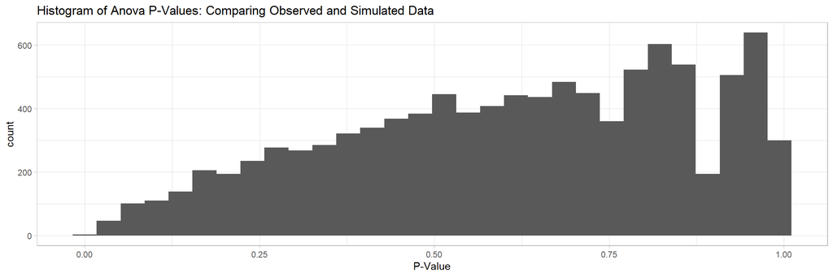

In the binomial distribution, the variance is defined as

$n*p*q$

Here are the observed and expected variances for each dose level in the data.

```
## # A tibble: 8 x 4
##   dose   p_obs obs_var expected_variance
##   <fct>  <dbl>   <dbl>             <dbl>
## 1 0     0.0308   0.397             0.298
## 2 0.4   0.292    1.54              2.07
## 3 0.8   0.315    1.47              2.16
## 4 1     0.375    0.932             2.34
## 5 1.6   0.564    4.05              2.46
## 6 2.4   0.655    2.27              2.26
## 7 3.2   0.845    3.87              1.31
## 8 3.84  0.964    0.455             0.350
```

To test whether the variances in the observed data are significantly different then what would be expected from a binomial distribution, we can do a very similar thing to the first analysis. We will again run a two-way anova, with the dose levels and sim/observed data at the two groups. This time, however, the measurements being compared are the absolute differences between each of the counts and the mean count per dose level. So, if the observed data is varying around each dose’s mean count to a larger or smaller extent than the sim data, many of these anova analyses should have low p-values. This analysis is an extension of Levene’s test, and is robust to non-normality. Again, we run an anova on the 10,000 simulated datasets.

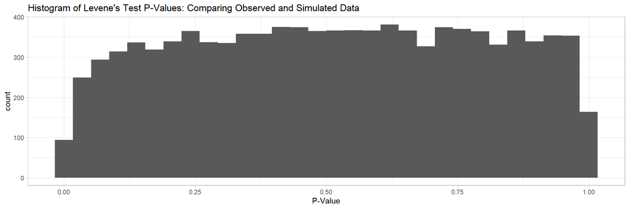

There doesn’t seem to be much here. The exact proportion of the 10,000 p-values that fell below the 0.05 threshold is 0.0335, which approaches the 5% level but falls far short. At this point, I’ve taken a couple of routes to testing how well the model is fit. From what I have seen here, making the assumption that the observed data is distributed binomial conditional on the dose level seems to be a valid assumption for this dataset.

2. Make the binomial assumption for mites at each dose and pool the data across groups. Then fit a dose-response curve of a standard type (e.g., probit, logit, complementary log-log, etc.), justifying your choice. That is, fit a generalized linear model (with glm in R, or with the python module statsmodels).

```
##
## Call:
## glm(formula = death_status ~ dose, family = binomial(link = "logit"),
##     data = by_mites)
##
## Deviance Residuals:
##     Min       1Q   Median       3Q      Max
## -2.3499  -0.8314  -0.5462   0.7917   1.9881
##
## Coefficients:
##             Estimate Std. Error z value Pr(>|z|)
## (Intercept) -1.82703    0.13386  -13.65   <2e-16 ***
## dose         1.17777    0.07796   15.11   <2e-16 ***
## ---
## Signif. codes:  0 '***' 0.001 '**' 0.01 '*' 0.05 '.' 0.1 ' ' 1
##
## (Dispersion parameter for binomial family taken to be 1)
##
##     Null deviance: 1302.5  on 939  degrees of freedom
## Residual deviance:  953.2  on 938  degrees of freedom
## AIC: 957.2
##
## Number of Fisher Scoring iterations: 4
```

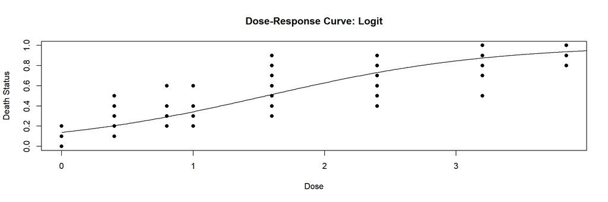

```
##
## Call:
## glm(formula = death_status ~ dose, family = binomial(link = "probit"),
##     data = by_mites)
##
## Deviance Residuals:
##     Min       1Q   Median       3Q      Max
## -2.4136  -0.8328  -0.5353   0.8085   2.0069
##
## Coefficients:
##             Estimate Std. Error z value Pr(>|z|)
## (Intercept) -1.11007    0.07625  -14.56   <2e-16 ***
## dose         0.70686    0.04238   16.68   <2e-16 ***
## ---
## Signif. codes:  0 '***' 0.001 '**' 0.01 '*' 0.05 '.' 0.1 ' ' 1
##
## (Dispersion parameter for binomial family taken to be 1)
##
##     Null deviance: 1302.50  on 939  degrees of freedom
## Residual deviance:  950.84  on 938  degrees of freedom
## AIC: 954.84
##
## Number of Fisher Scoring iterations: 4
```

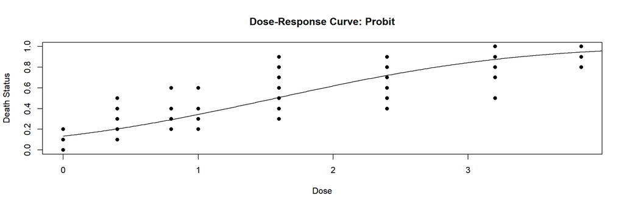

3. Estimate the LD50 (the dose at which the probability of death is 50%) and its standard error (SE).

I reasearched for a while on how to estimate the standard error for LD50. I found it difficult to find an explanation of how to calculate the closed-form solution in that case. For these reasons, I will estimate LD50 and its standard error via boostrap instead.

```
##
## ORDINARY NONPARAMETRIC BOOTSTRAP
##
##
## Call:
## boot(data = by_mites, statistic = ld50_boot, R = 1000)
##
##
## Bootstrap Statistics :
##     original       bias    std. error
## t1*  1.57042 -0.002952566  0.06669165
```

4. How might you need to modify your analyses in (b) and (c) in light of your conclusions in (a)?

Since I concluded in (a) that I could find no reason to doubt the data were generated as independent observtions from a binomial distribution, there’s no adjustments that need to be done here, given that this is the exact assumption made by logistic regression.

5. Repeat (a)-(d) for data on a second strain of mites, in hw1_mitesB.txt.

Here is the data visualized:

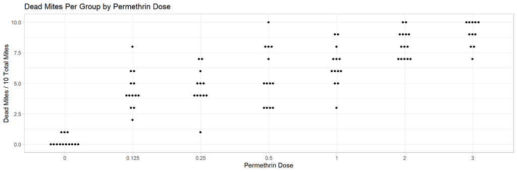

Here’s number of experiments that were done at each doseage.

```
## # A tibble: 7 x 2
##   dose  number_of_experiments
##   <fct>                 <int>
## 1 0                        13
## 2 0.125                    13
## 3 0.25                     12
## 4 0.5                      13
## 5 1                        13
## 6 2                        14
## 7 3                        11
```

Run a goodness of fit test on the data.

Again, there’s not much here. With 77 degrees of freedom, a 5% alpha gives us a critical value of 97.351, which is far above the calculated chi-squared statistic of 69.392 This result provides no evidence aginst the binomial model being an appropriate fit for the data.

Now estimate the means for each dose level from the data.

```
## # A tibble: 7 x 2
##   dose  p_dose
##   <fct>  <dbl>
## 1 0     0.0231
## 2 0.125 0.446
## 3 0.25  0.467
## 4 0.5   0.562
## 5 1     0.646
## 6 2     0.821
## 7 3     0.909
```

Simulate the dataset.

Run two-way anova.

The proportion of the 10,000 p-values that fell below the 0.05 threshold is 0.0033. There is again no evidence here the observed data is poorly described by my model.

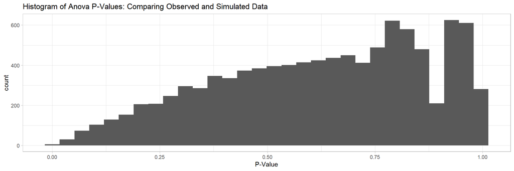

Here are the observed and expected variances for each dose level in the data.

```
## # A tibble: 7 x 4
##   dose   p_obs obs_var expected_variance
##   <fct>  <dbl>   <dbl>             <dbl>
## 1 0     0.0231   0.192             0.225
## 2 0.125 0.446    2.44              2.47
## 3 0.25  0.467    2.61              2.49
## 4 0.5   0.562    5.59              2.46
## 5 1     0.646    2.77              2.29
## 6 2     0.821    1.26              1.47
## 7 3     0.909    1.09              0.826
```

Again, we run Leveine’s test on the 10,000 simulated datasets.

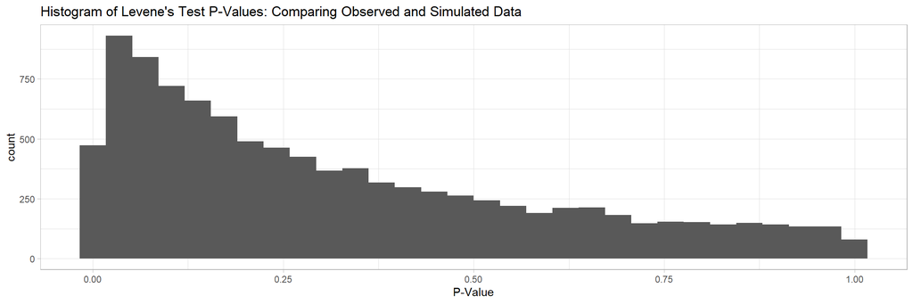

Again fit the logit model

```
##
## Call:
## glm(formula = death_status ~ dose, family = binomial(link = "logit"),
##     data = by_mites)
##
## Deviance Residuals:
##     Min       1Q   Median       3Q      Max
## -2.4177  -0.9169   0.3325   1.0046   1.5314
##
## Coefficients:
##             Estimate Std. Error z value Pr(>|z|)
## (Intercept)  -0.8021     0.1013  -7.919 2.39e-15 ***
## dose          1.2232     0.1029  11.886  < 2e-16 ***
## ---
## Signif. codes:  0 '***' 0.001 '**' 0.01 '*' 0.05 '.' 0.1 ' ' 1
##
## (Dispersion parameter for binomial family taken to be 1)
##
##     Null deviance: 1225.1  on 889  degrees of freedom
## Residual deviance: 1011.0  on 888  degrees of freedom
## AIC: 1015
##
## Number of Fisher Scoring iterations: 4
```

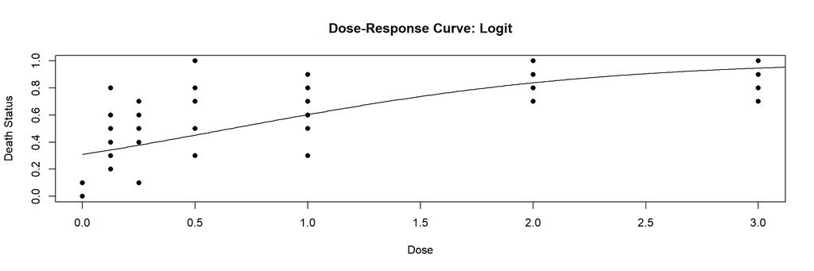

3. Estimate the LD50 (the dose at which the probability of death is 50%) and its standard error (SE).

I reasearched for a while on how to estimate the standard error for LD50. I found it difficult to find an explanation of how to calculate the closed-form solution in that case. For these reasons, I will estimate LD50 and its standard error via boostrap instead.

```
##
## ORDINARY NONPARAMETRIC BOOTSTRAP
##
##
## Call:
## boot(data = by_mites, statistic = ld50_boot, R = 1000)
##
##
## Bootstrap Statistics :
##      original        bias    std. error
## t1* 0.6806151 -0.0006627869  0.06584488
```

4. Ultimately, this is data with binary outcomes, so a parametric curve cannot be fit much more accurately than by a logistic or probit regression. However, the violations of the binomial distribution I have observed mean the estimates of error in the logistic model will be too low. This should be noted at the very least. Fitting a curve using a non-parametric method and comparing the errors to the logistic model might be informative to see how great the over-estimation of error is.
5. Assess whether the does-response curves for the two strains are parallel.

To test whether the curves for the two strains are parallel, I run a regression including both datasets, with an indicator variable designating the two strains, and an interaction term. If the coefficient on the indicator term is significant, this demonstrates that the intercepts are different between the two strains. If the coefficient on the interaction term is significant, this will indicate a difference in slopes. As can be seen, there is no significance on the interaction term, and so there is no evidence here that the slopes of the two dose-response curves are different.

```
##
## Call:
## glm(formula = death_status ~ dose + strain + dose * strain, family = binomial(link = "logit"),
##     data = by_mites_all)
##
## Deviance Residuals:
##     Min       1Q   Median       3Q      Max
## -2.4177  -0.8608   0.3325   1.0046   1.9881
##
## Coefficients:
##             Estimate Std. Error z value Pr(>|z|)
## (Intercept) -0.80208    0.10128  -7.919 2.39e-15 ***
## dose         1.22316    0.10291  11.886  < 2e-16 ***
## strain      -1.02495    0.16786  -6.106 1.02e-09 ***
## dose:strain -0.04539    0.12911  -0.352    0.725
## ---
## Signif. codes:  0 '***' 0.001 '**' 0.01 '*' 0.05 '.' 0.1 ' ' 1
##
## (Dispersion parameter for binomial family taken to be 1)
##
##     Null deviance: 2534.7  on 1829  degrees of freedom
## Residual deviance: 1964.2  on 1826  degrees of freedom
## AIC: 1972.2
##
## Number of Fisher Scoring iterations: 4
```